# comparison of RSM and PCM

Chun Hsien Wu

2021年12月13日

2021.12.14

# Partial Credit Model

learning TAM package's function about comparison of RSM and PCM website https://bookdown.org/dkatz/Rasch_Biome/polytomous-items.html#polytymous-item-types-and-the-partial-credit-model

```r
library(TAM)
setwd("/home/son/刻意練習/統計模擬_實做/Measuring_what_matters")

hls2 <- read.csv("https://raw.githubusercontent.com/danielbkatz/DBER_Rasch-data/master/data/hls_poly_scale.csv")

View(hls2)
```

hls2's dimension is 317*16 學習用 apply function 把資料集 各個試題答題得分的個數加總 呈現

```r
apply(hls2, 2, table)
```

```
##   Hls1 Hls2 Hls3 Hls4 Hls5 Hls6 Hls7 Hls8 Hls9 Hls10 Hls11 Hls12 Hls13 Hls14
## 0   63   76  129  160   65   90  140   50  146   139    47    44    52    64
## 1  204  207  176  148  166  196  162  154  144   163   116   138   176   181
## 2   44   32   11    7   78   26   12  101   21    13   130   119    83    60
## 3    6    2    1    2    8    5    3   12    6     2    24    16     6    12
##   Hls15 Hls16
## 0    52    69
## 1   148   185
## 2   105    57
## 3    12     6
```

the author mentioned that TAM will automatically run the PCM when our data is polytomous. (Now, I got it!)

```r
mod_pcm <- tam(hls2)
```

[output not shown]

[output cut: 532 more lines]

```
##      [,1]
## [1,]    0
##
## Variance:
##       [,1]
## [1,] 2.615
##
##
## EAP Reliability:
## [1] 0.914
##
## -----------------------------
## Start:  2021-12-19 12:06:32
## End:  2021-12-19 12:06:33
## Time difference of 0.3800521 secs
```

```r
summary(mod_pcm)
```

```
## ------------------------------------------------------------
## TAM 3.7-16 (2021-06-24 14:31:37)
## R version 3.6.3 (2020-02-29) x86_64, linux-gnu | nodename=son-K50ID | login=unknown
##
## Date of Analysis: 2021-12-19 12:06:33
## Time difference of 0.3800521 secs
## Computation time: 0.3800521
##
## Multidimensional Item Response Model in TAM
##
## IRT Model: 1PL
## Call:
## tam.mml(resp = resp)
##
## ------------------------------------------------------------
## Number of iterations = 57
## Numeric integration with 21 integration points
##
## Deviance = 8371.25
## Log likelihood = -4185.63
## Number of persons = 317
## Number of persons used = 317
## Number of items = 16
## Number of estimated parameters = 49
##     Item threshold parameters = 48
##     Item slope parameters = 0
##     Regression parameters = 0
##     Variance/covariance parameters = 1
##
## AIC = 8469  | penalty=98    | AIC=-2*LL + 2*p
## AIC3 = 8518  | penalty=147    | AIC3=-2*LL + 3*p
## BIC = 8653  | penalty=282.19    | BIC=-2*LL + log(n)*p
## aBIC = 8497  | penalty=126.15    | aBIC=-2*LL + log((n-2)/24)*p  (adjusted BIC)
## CAIC = 8702  | penalty=331.19    | CAIC=-2*LL + [log(n)+1]*p  (consistent AIC)
## AICc = 8488  | penalty=116.35    | AICc=-2*LL + 2*p + 2*p*(p+1)/(n-p-1)  (bias corrected AIC)
## GHP = 0.8349     | GHP=( -LL + p ) / (#Persons * #Items)  (Gilula-Haberman log penalty)
##
## ------------------------------------------------------------
## EAP Reliability
## [1] 0.914
```

[output cut: 103 more lines]

```
## 2   Hls2     1 2.074   -3.575    0.691    2.885
## 3   Hls3     1 2.903   -3.284    1.059    2.224
## 4   Hls4     1 2.809   -2.633    1.515    1.118
## 5   Hls5     1 1.198   -2.883    0.184    2.699
## 6   Hls6     1 1.818   -2.974    1.121    1.853
## 7   Hls7     1 2.455   -2.620    1.299    1.322
## 8   Hls8     1 0.781   -2.917    0.116    2.800
## 9   Hls9     1 2.098   -2.106    0.891    1.215
## 10 Hls10     1 2.630   -2.814    1.065    1.749
## 11 Hls11     1 0.325   -2.431   -0.152    2.583
## 12 Hls12     1 0.513   -2.830    0.001    2.830
## 13 Hls13     1 1.162   -3.290    0.176    3.113
## 14 Hls14     1 1.070   -2.831    0.692    2.139
## 15 Hls15     1 0.792   -2.835    0.018    2.816
## 16 Hls16     1 1.434   -3.063    0.472    2.590
```

two forms of Partial Credit Model:

$\theta$ is the latent trait of person $n$.

$X_i$ means person $n$ get $X$ points ($x$ = 0,1, ..., $m_i$) on item i.

$P(X_{ni} = x) = \frac{exp[\sum_{k=0}^x(\theta_n-\delta_{ik})]}{\sum_{h=0}^{m_i}exp[\sum_{k=0}^h(\theta_n-\delta_{ik})]}$

The second form of Partial Credit Model

$P(X_{ni} = x) = \frac{exp[\sum_{k=0}^x(\theta_n-(\delta_{i}+\tau_{ik})]}{\sum_{h=0}^{m_i}exp[\sum_{k=0}^h(\theta_n-(\delta_{i} + \tau_{ik})]}$

$\delta_{i}$是整體試題難度

$\tau_{ik}$ 為試題 $i$ 在第 $j$ 閾值的難度

## PCM (Item difficulty)

這裡 $\delta_{ik}$ 就是 TAM報表中的 xsi

```r
# Deltas
xsi <- mod_pcm$xsi
xsi
```

```
##                     xsi    se.xsi
## Hls1_Cat1  -1.846046710 0.1770841
## Hls1_Cat2   2.298334842 0.1736858
## Hls1_Cat3   3.830385868 0.4635448
## Hls2_Cat1  -1.501715752 0.1640914
## Hls2_Cat2   2.764560868 0.2004621
## Hls2_Cat3   4.958324889 0.7804292
## Hls3_Cat1  -0.380834628 0.1378983
## Hls3_Cat2   3.962213547 0.3205437
## Hls3_Cat3   5.127428610 1.1165768
## Hls4_Cat1   0.175976124 0.1331498
## Hls4_Cat2   4.324558567 0.3775359
## Hls4_Cat3   3.927492901 0.8526291
## Hls5_Cat1  -1.684131262 0.1781274
## Hls5_Cat2   1.381933373 0.1467223
## Hls5_Cat3   3.897482578 0.3943440
## Hls6_Cat1  -1.155351142 0.1543659
## Hls6_Cat2   2.939344680 0.2113184
## Hls6_Cat3   3.671463609 0.5189345
## Hls7_Cat1  -0.165823435 0.1358793
## Hls7_Cat2   3.753328170 0.2949727
## Hls7_Cat3   3.776319530 0.6885511
## Hls8_Cat1  -2.135935885 0.1992731
## Hls8_Cat2   0.896643565 0.1385362
## Hls8_Cat3   3.581083599 0.3235907
## Hls9_Cat1  -0.008019089 0.1360316
## Hls9_Cat2   2.989853095 0.2288433
## Hls9_Cat3   3.313295753 0.4819018
## Hls10_Cat1 -0.183297684 0.1360561
## Hls10_Cat2  3.694746057 0.2921816
## Hls10_Cat3  4.379242422 0.8215605
## Hls11_Cat1 -2.106058995 0.2097751
## Hls11_Cat2  0.172650186 0.1377271
## Hls11_Cat3  2.907183948 0.2353937
## Hls12_Cat1 -2.317865929 0.2117123
## Hls12_Cat2  0.513325662 0.1362435
## Hls12_Cat3  3.342199604 0.2821645
## Hls13_Cat1 -2.127336182 0.1938394
## Hls13_Cat2  1.338677184 0.1444056
## Hls13_Cat3  4.275574749 0.4493420
## Hls14_Cat1 -1.761463128 0.1777770
## Hls14_Cat2  1.762102813 0.1550751
## Hls14_Cat3  3.208316423 0.3314447
## Hls15_Cat1 -2.042459839 0.1969236
## Hls15_Cat2  0.810466042 0.1380178
## Hls15_Cat3  3.608588261 0.3230206
## Hls16_Cat1 -1.628691156 0.1721913
## Hls16_Cat2  1.906727817 0.1604086
## Hls16_Cat3  4.024764112 0.4574405
```

Here, TAM's xsi result is actually $\delta_{ik}$. This is item difficulty.

Note that, $\delta_{ik}=\delta_{i}+\tau_{ik}$. In TAM'result.

beta is exactly $\delta_{i}$, tau.Cat1 is $\tau_{i1}$, tau.Cat2 is $\tau_{i2}$, respectively.

這裡 TAM報表中的beta 就是PCM公式中的 $\delta_i$(整體試題難度)

TAM報表中的 tau.cat1 就是PCM公式中的 $\tau_{i1}$ 第$i$題的第一 階梯難度(step difficulty)或稱為閾難度(threshold difficulty)

```r
# Delta-tau parameters
delta_tau <- mod_pcm$item_irt
delta_tau
```

```
##     item alpha      beta  tau.Cat1      tau.Cat2 tau.Cat3
## 1   Hls1     1 1.4275580 -3.273605  0.8707768417 2.402828
## 2   Hls2     1 2.0737233 -3.575439  0.6908375329 2.884602
## 3   Hls3     1 2.9029358 -3.283770  1.0592777038 2.224493
## 4   Hls4     1 2.8093425 -2.633366  1.5152160365 1.118150
## 5   Hls5     1 1.1984282 -2.882559  0.1835051436 2.699054
## 6   Hls6     1 1.8184857 -2.973837  1.1208589647 1.852978
## 7   Hls7     1 2.4546081 -2.620432  1.2987200814 1.321711
## 8   Hls8     1 0.7805971 -2.916533  0.1160464719 2.800487
## 9   Hls9     1 2.0983766 -2.106396  0.8914765089 1.214919
## 10 Hls10     1 2.6302303 -2.813528  1.0645157918 1.749012
## 11 Hls11     1 0.3245917 -2.430651 -0.1519415271 2.582592
## 12 Hls12     1 0.5125531 -2.830419  0.0007725496 2.829646
## 13 Hls13     1 1.1623053 -3.289641  0.1763719337 3.113269
## 14 Hls14     1 1.0696520 -2.831115  0.6924507772 2.138664
## 15 Hls15     1 0.7921982 -2.834658  0.0182678876 2.816390
## 16 Hls16     1 1.4342669 -3.062958  0.4724608924 2.590497
```

We can see that Hls1_Cat1, Hls1_Cat2 and Hls1_Cat3' value are -1.847, 2.298 and 3.83 respectively.

Now, we can look at Hls1, beta equals 1.4275. It refers to item difficulty. Tau.Cat1, tau.Cat2 and tau.Cat3's value is -3.2736.5, 0.87077 and 2.402828, respectively.

Then Hls1_Cat1 =-1.847 = beta + tau.Cat1 = 1.4275 + -3.273605

```r
mod_pcm$item #PCM2 type parameters
```

```
##        item   N         M  xsi.item   AXsi_.Cat1    AXsi_.Cat2 AXsi_.Cat3
## Hls1   Hls1 317 0.9779180 1.4275580 -1.846046710  0.4522881319  4.2826740
## Hls2   Hls2 317 0.8738170 2.0737233 -1.501715752  1.2628451156  6.2211700
## Hls3   Hls3 317 0.6340694 2.9029358 -0.380834628  3.5813789194  8.7088075
## Hls4   Hls4 317 0.5299685 2.8093425  0.175976124  4.5005346907  8.4280276
## Hls5   Hls5 317 1.0914826 1.1984282 -1.684131262 -0.3021978893  3.5952847
## Hls6   Hls6 317 0.8296530 1.8184857 -1.155351142  1.7839935377  5.4554571
## Hls7   Hls7 317 0.6151420 2.4546081 -0.165823435  3.5875047349  7.3638243
## Hls8   Hls8 317 1.2365931 0.7805971 -2.135935885 -1.2392923205  2.3417913
## Hls9   Hls9 317 0.6435331 2.0983766 -0.008019089  2.9818340054  6.2951298
## Hls10 Hls10 317 0.6151420 2.6302303 -0.183297684  3.5114483724  7.8906908
## Hls11 Hls11 317 1.4132492 0.3245917 -2.106058995 -1.9334088090  0.9737751
## Hls12 Hls12 317 1.3375394 0.5125531 -2.317865929 -1.8045402672  1.5376593
## Hls13 Hls13 317 1.1356467 1.1623053 -2.127336182 -0.7886589975  3.4869158
## Hls14 Hls14 317 1.0630915 1.0696520 -1.761463128  0.0006396845  3.2089561
## Hls15 Hls15 317 1.2429022 0.7921982 -2.042459839 -1.2319937970  2.3765945
## Hls16 Hls16 317 1.0000000 1.4342669 -1.628691156  0.2780366612  4.3028008
##       B.Cat1.Dim1 B.Cat2.Dim1 B.Cat3.Dim1
## Hls1            1           2           3
## Hls2            1           2           3
## Hls3            1           2           3
## Hls4            1           2           3
## Hls5            1           2           3
## Hls6            1           2           3
## Hls7            1           2           3
## Hls8            1           2           3
## Hls9            1           2           3
## Hls10           1           2           3
## Hls11           1           2           3
## Hls12           1           2           3
## Hls13           1           2           3
## Hls14           1           2           3
## Hls15           1           2           3
## Hls16           1           2           3
```

## PCM (Person ability estimates)

```r
WLE.ability.poly <- tam.wle(mod_pcm)
```

```
## Iteration in WLE/MLE estimation  1   | Maximal change  2.6968
## Iteration in WLE/MLE estimation  2   | Maximal change  2.1778
## Iteration in WLE/MLE estimation  3   | Maximal change  0.368
## Iteration in WLE/MLE estimation  4   | Maximal change  0.0135
## Iteration in WLE/MLE estimation  5   | Maximal change  3e-04
## Iteration in WLE/MLE estimation  6   | Maximal change  0
## ----
##  WLE Reliability= 0.9
```

```r
person.ability.poly <- WLE.ability.poly$theta
head(person.ability.poly)
```

```
## [1]  0.07678935  1.74469602  0.29335469 -0.14098024  0.07678935  1.14378242
```

## PCM (Item fit statistics)

```r
Fit.poly <- tam.fit(mod_pcm)
```

```
## Item fit calculation based on 100 simulations
## |**********|
## |----------|
```

```r
Fit.poly$itemfit
```

```
##     parameter       Outfit   Outfit_t     Outfit_p Outfit_pholm     Infit
## 1   Hls1_Cat1 3.104273e+00 11.6381776 2.635875e-31 1.133426e-29 1.0296347
## 2   Hls1_Cat2 3.497553e+00 13.1667706 1.363044e-39 5.997392e-38 1.1278940
## 3   Hls1_Cat3 3.241332e+03 79.0622395 0.000000e+00 0.000000e+00 0.9625053
## 4   Hls2_Cat1 1.913770e+01 45.8613212 0.000000e+00 0.000000e+00 1.0723049
## 5   Hls2_Cat2 9.218564e-01 -0.6038977 5.459116e-01 1.000000e+00 1.0392410
## 6   Hls2_Cat3 8.020040e-01 -0.2585470 7.959848e-01 1.000000e+00 1.4227524
## 7   Hls3_Cat1 9.221656e-01 -1.2506722 2.110541e-01 1.000000e+00 0.9594616
## 8   Hls3_Cat2 8.370313e-01 -0.6617275 5.081459e-01 1.000000e+00 0.9132440
## 9   Hls3_Cat3 1.512783e-02 -2.4321582 1.500915e-02 3.752288e-01 0.8998996
## 10  Hls4_Cat1 8.664447e-01 -2.5622189 1.040057e-02 3.016167e-01 0.9280049
## 11  Hls4_Cat2 6.565732e-01 -1.2559764 2.091245e-01 1.000000e+00 0.8903488
## 12  Hls4_Cat3 1.048223e-02 -3.4025633 6.675689e-04 2.336491e-02 0.4147266
## 13  Hls5_Cat1 8.364372e-01 -1.7130891 8.669615e-02 1.000000e+00 0.8444424
## 14  Hls5_Cat2 1.741411e+00  7.5904553 3.187834e-14 1.275134e-12 1.0784289
```

[output cut: 83 more lines]

## Plot and look at difficulties/thresholds

```
## Iteration in WLE/MLE estimation  1   | Maximal change  2.6968
## Iteration in WLE/MLE estimation  2   | Maximal change  2.1778
## Iteration in WLE/MLE estimation  3   | Maximal change  0.368
## Iteration in WLE/MLE estimation  4   | Maximal change  0.0135
## Iteration in WLE/MLE estimation  5   | Maximal change  3e-04
## Iteration in WLE/MLE estimation  6   | Maximal change  0
## ----
##  WLE Reliability= 0.9
```

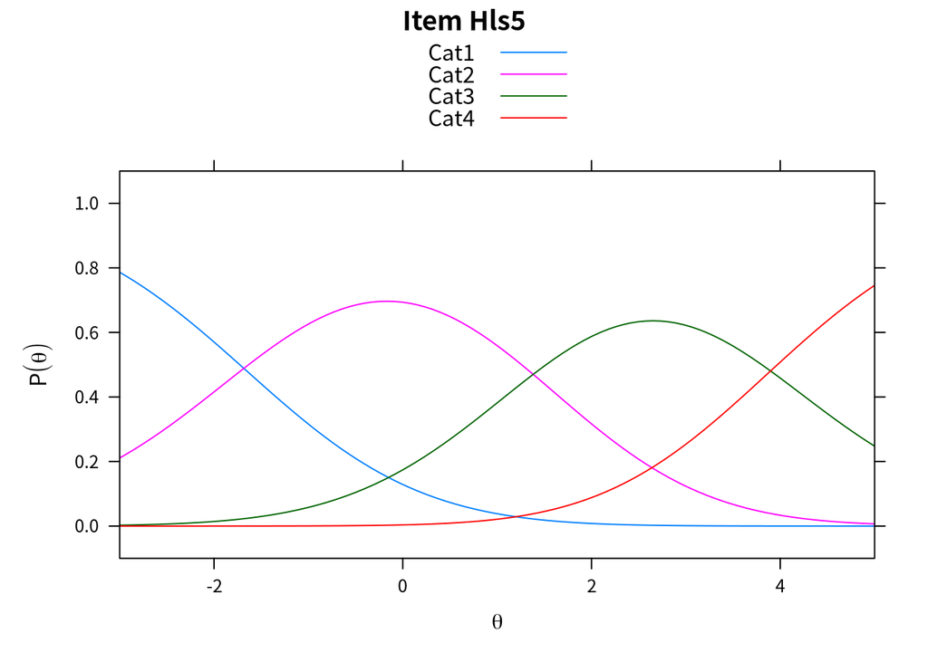

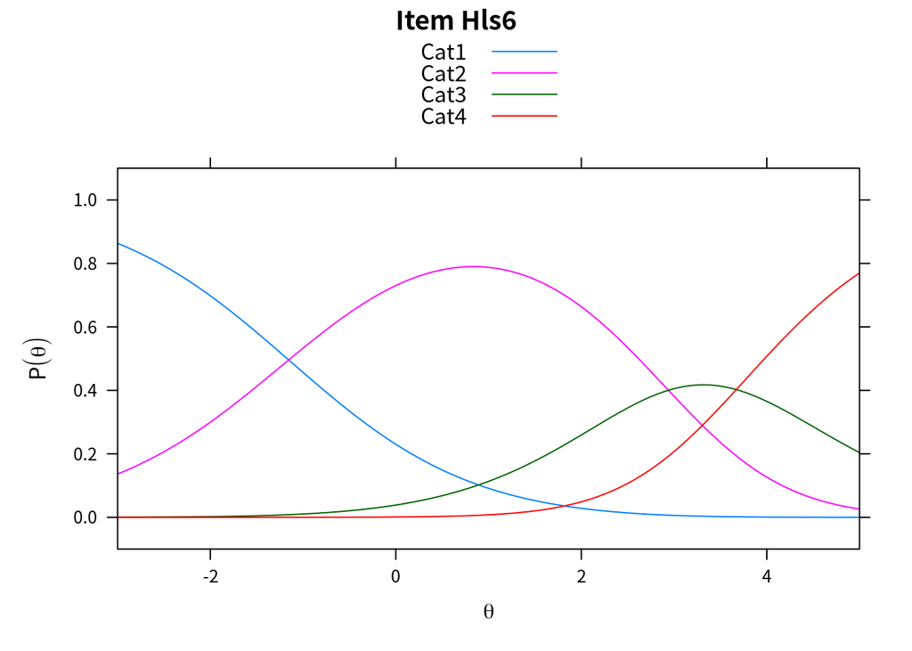

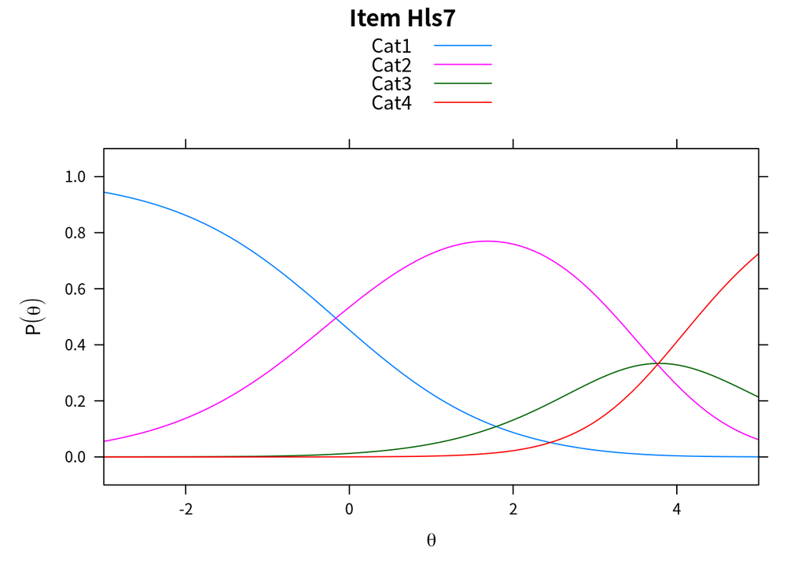

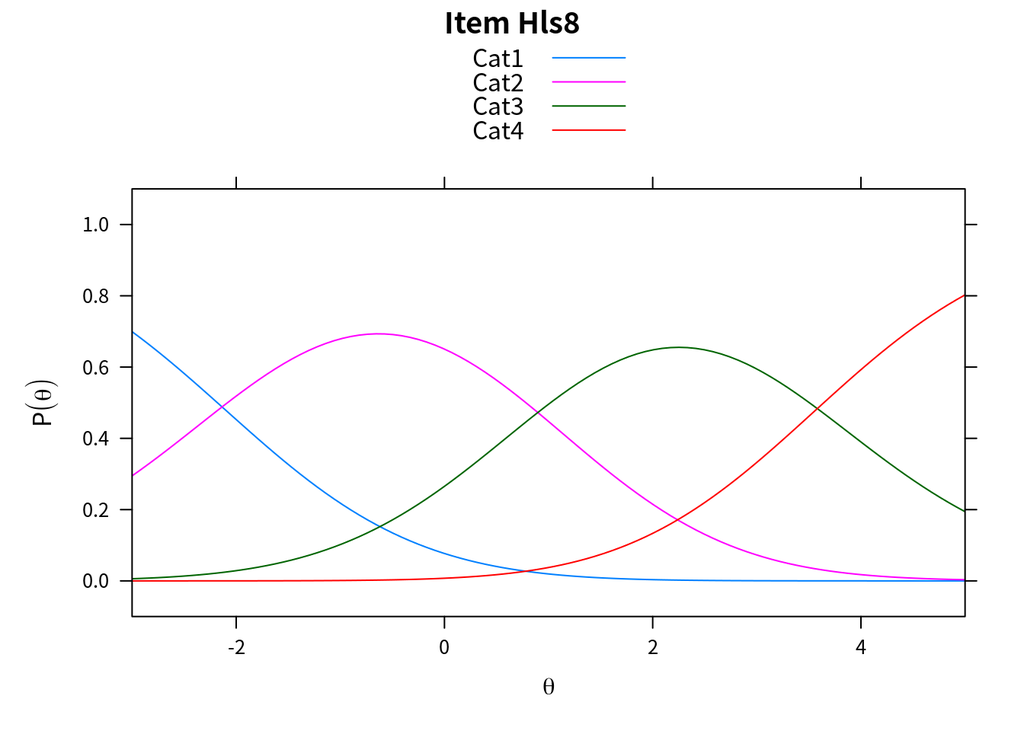

```r
# just look at a few items - items 5-8
plot(mod_pcm, type = "items", export = F, high = 5, items = c(5:8))
```

## extract item steps/adjacent category difficulties

```r
xsi_pcm <- mod_pcm$xsi
head(xsi_pcm)
```

```
##                 xsi    se.xsi
## Hls1_Cat1 -1.846047 0.1770841
## Hls1_Cat2  2.298335 0.1736858
## Hls1_Cat3  3.830386 0.4635448
## Hls2_Cat1 -1.501716 0.1640914
## Hls2_Cat2  2.764561 0.2004621
## Hls2_Cat3  4.958325 0.7804292
```

## Rating Scale

評定量尺模式的公式如下

$$P(X_{nij} = x) =\frac{exp[\sum_{j=0}^x(\theta_n-\delta_i-\tau_j)]}{\sum_{h=0}^{m_i}exp[\sum_{k=0}^h(\theta_n-\delta_{i} -\tau_j]}$$
若以勝率(odds)對數公式表示則為
$$log\frac{P_{nij}}{P_{ni(j-1)}} = \theta_n - (\delta_i + \tau_j)$$
$\theta_n$表示受試者的能力值;

$\delta_i$為第$i$題的整體難度

$\tau_j$為整份測驗所有試題從得到$j-1$分到$j$分的閾值難度 或稱為階梯難度(step difficulty) $P_{nij}$與 $P_{ni(j-1)}$ 表示受試者$n$在第$i$題得到$j$分和$j-1$分的機率

```r
# run the Rating Scale Model
mod_rsm <- tam.mml(hls2, irtmodel="RSM")
```

[output not shown]

[output cut: 736 more lines]

```
##      [,1]
## [1,]    0
##
## Variance:
##       [,1]
## [1,] 2.737
##
##
## EAP Reliability:
## [1] 0.918
##
## -----------------------------
## Start:  2021-12-19 12:06:35
## End:  2021-12-19 12:06:36
## Time difference of 0.4201505 secs
```

以下可以看到評定量尺模型各試題的難度,同時把部份給分模型模型二的各個試題的整體難度與評定量尺模型各個試題的難度並列加以比較

```r
xsi_rsm <- mod_rsm$xsi[1:16,1]
comp_rsm_pcm_diff<-cbind(xsi_rsm, mod_pcm$item[,4])
# add colnames name
colnames(comp_rsm_pcm_diff) <- c("RSM", "PCM")
comp_rsm_pcm_diff
```

```
##             RSM       PCM
##  [1,] 1.5377201 1.4275580
##  [2,] 1.9185631 2.0737233
##  [3,] 2.8627530 2.9029358
##  [4,] 3.3041545 2.8093425
##  [5,] 1.1435768 1.1984282
##  [6,] 2.0856246 1.8184857
##  [7,] 2.9413247 2.4546081
##  [8,] 0.6707580 0.7805971
##  [9,] 2.8237128 2.0983766
## [10,] 2.9413247 2.6302303
## [11,] 0.1334497 0.3245917
## [12,] 0.3593760 0.5125531
## [13,] 0.9961908 1.1623053
## [14,] 1.2400379 1.0696520
## [15,] 0.6509113 0.7921982
## [16,] 1.4593359 1.4342669
```